# Risk Factor Analysis

## Outcome Variable

**Outcome Variable:** stunted

## Predictor Variables

**Intervention Variable:** impfloor

**Adjustment Set:**

- arm
- sex
- W_mage
- meducyrs
- feducyrs
- hhwealth_quart
- hfoodsec
- W_mhtcm
- W_nrooms
- W_nchldlt5
- W_parity
- impsan
- safeh20
- delta_W_mage
- delta_meducyrs
- delta_feducyrs
- delta_hhwealth_quart
- delta_hfoodsec
- delta_W_mhtcm
- delta_W_nrooms
- delta_W_nchldlt5
- delta_W_parity
- delta_impsan
- delta_safeh20

## Stratifying Variables

The analysis was stratified on these variable(s):

- agecat
- studyid
- country

## Data Summary

| agecat | studyid | country | impfloor | stunted | n_cell | n |
| --- | --- | --- | --- | --- | --- | --- |
| Birth | ki0047075b-MAL-ED | BANGLADESH | 1 | 0 | 180 | 234 |
| Birth | ki0047075b-MAL-ED | BANGLADESH | 1 | 1 | 36 | 234 |
| Birth | ki0047075b-MAL-ED | BANGLADESH | 0 | 0 | 16 | 234 |
| Birth | ki0047075b-MAL-ED | BANGLADESH | 0 | 1 | 2 | 234 |
| Birth | ki0047075b-MAL-ED | BRAZIL | 1 | 0 | 155 | 174 |
| Birth | ki0047075b-MAL-ED | BRAZIL | 1 | 1 | 17 | 174 |
| Birth | ki0047075b-MAL-ED | BRAZIL | 0 | 0 | 2 | 174 |
| Birth | ki0047075b-MAL-ED | BRAZIL | 0 | 1 | 0 | 174 |
| Birth | ki0047075b-MAL-ED | INDIA | 1 | 0 | 152 | 191 |
| Birth | ki0047075b-MAL-ED | INDIA | 1 | 1 | 29 | 191 |
| Birth | ki0047075b-MAL-ED | INDIA | 0 | 0 | 9 | 191 |
| Birth | ki0047075b-MAL-ED | INDIA | 0 | 1 | 1 | 191 |
| Birth | ki0047075b-MAL-ED | NEPAL | 1 | 0 | 56 | 164 |
| Birth | ki0047075b-MAL-ED | NEPAL | 1 | 1 | 10 | 164 |
| Birth | ki0047075b-MAL-ED | NEPAL | 0 | 0 | 91 | 164 |
| Birth | ki0047075b-MAL-ED | NEPAL | 0 | 1 | 7 | 164 |
| Birth | ki0047075b-MAL-ED | PERU | 1 | 0 | 46 | 259 |
| Birth | ki0047075b-MAL-ED | PERU | 1 | 1 | 10 | 259 |
| Birth | ki0047075b-MAL-ED | PERU | 0 | 0 | 182 | 259 |
| Birth | ki0047075b-MAL-ED | PERU | 0 | 1 | 21 | 259 |
| Birth | ki0047075b-MAL-ED | SOUTH AFRICA | 1 | 0 | 176 | 218 |
| Birth | ki0047075b-MAL-ED | SOUTH AFRICA | 1 | 1 | 21 | 218 |
| Birth | ki0047075b-MAL-ED | SOUTH AFRICA | 0 | 0 | 20 | 218 |
| Birth | ki0047075b-MAL-ED | SOUTH AFRICA | 0 | 1 | 1 | 218 |
| Birth | ki0047075b-MAL-ED | TANZANIA, UNITED REPUBLIC OF | 1 | 0 | 7 | 117 |
| Birth | ki0047075b-MAL-ED | TANZANIA, UNITED REPUBLIC OF | 1 | 1 | 1 | 117 |
| Birth | ki0047075b-MAL-ED | TANZANIA, UNITED REPUBLIC OF | 0 | 0 | 94 | 117 |
| Birth | ki0047075b-MAL-ED | TANZANIA, UNITED REPUBLIC OF | 0 | 1 | 15 | 117 |
| Birth | ki1000108-CMC-V-BCS-2002 | INDIA | 1 | 0 | 58 | 71 |
| Birth | ki1000108-CMC-V-BCS-2002 | INDIA | 1 | 1 | 13 | 71 |

[output cut: 154 more lines]

The following strata were considered:

- agecat: 24 months, studyid: ki0047075b-MAL-ED, country: BANGLADESH
- agecat: 24 months, studyid: ki0047075b-MAL-ED, country: BRAZIL
- agecat: 24 months, studyid: ki0047075b-MAL-ED, country: INDIA
- agecat: 24 months, studyid: ki0047075b-MAL-ED, country: NEPAL
- agecat: 24 months, studyid: ki0047075b-MAL-ED, country: PERU
- agecat: 24 months, studyid: ki0047075b-MAL-ED, country: SOUTH AFRICA
- agecat: 24 months, studyid: ki0047075b-MAL-ED, country: TANZANIA, UNITED REPUBLIC OF
- agecat: 24 months, studyid: ki1000108-CMC-V-BCS-2002, country: INDIA
- agecat: 24 months, studyid: ki1000108-IRC, country: INDIA
- agecat: 24 months, studyid: ki1017093-NIH-Birth, country: BANGLADESH
- agecat: 24 months, studyid: ki1017093b-PROVIDE, country: BANGLADESH
- agecat: 24 months, studyid: ki1017093c-NIH-Crypto, country: BANGLADESH
- agecat: 24 months, studyid: ki1113344-GMS-Nepal, country: NEPAL
- agecat: 24 months, studyid: ki1114097-CONTENT, country: PERU
- agecat: 24 months, studyid: kiGH5241-JiVitA-3, country: BANGLADESH
- agecat: 24 months, studyid: kiGH5241-JiVitA-4, country: BANGLADESH
- agecat: 6 months, studyid: ki0047075b-MAL-ED, country: BANGLADESH
- agecat: 6 months, studyid: ki0047075b-MAL-ED, country: BRAZIL
- agecat: 6 months, studyid: ki0047075b-MAL-ED, country: INDIA
- agecat: 6 months, studyid: ki0047075b-MAL-ED, country: NEPAL
- agecat: 6 months, studyid: ki0047075b-MAL-ED, country: PERU
- agecat: 6 months, studyid: ki0047075b-MAL-ED, country: SOUTH AFRICA
- agecat: 6 months, studyid: ki0047075b-MAL-ED, country: TANZANIA, UNITED REPUBLIC OF
- agecat: 6 months, studyid: ki1000108-CMC-V-BCS-2002, country: INDIA
- agecat: 6 months, studyid: ki1000108-IRC, country: INDIA
- agecat: 6 months, studyid: ki1017093-NIH-Birth, country: BANGLADESH
- agecat: 6 months, studyid: ki1017093b-PROVIDE, country: BANGLADESH
- agecat: 6 months, studyid: ki1017093c-NIH-Crypto, country: BANGLADESH
- agecat: 6 months, studyid: ki1113344-GMS-Nepal, country: NEPAL
- agecat: 6 months, studyid: ki1114097-CONTENT, country: PERU
- agecat: 6 months, studyid: kiGH5241-JiVitA-3, country: BANGLADESH
- agecat: 6 months, studyid: kiGH5241-JiVitA-4, country: BANGLADESH
- agecat: Birth, studyid: ki0047075b-MAL-ED, country: BANGLADESH
- agecat: Birth, studyid: ki0047075b-MAL-ED, country: BRAZIL
- agecat: Birth, studyid: ki0047075b-MAL-ED, country: INDIA
- agecat: Birth, studyid: ki0047075b-MAL-ED, country: NEPAL
- agecat: Birth, studyid: ki0047075b-MAL-ED, country: PERU
- agecat: Birth, studyid: ki0047075b-MAL-ED, country: SOUTH AFRICA
- agecat: Birth, studyid: ki0047075b-MAL-ED, country: TANZANIA, UNITED REPUBLIC OF
- agecat: Birth, studyid: ki1000108-CMC-V-BCS-2002, country: INDIA
- agecat: Birth, studyid: ki1000108-IRC, country: INDIA
- agecat: Birth, studyid: ki1017093-NIH-Birth, country: BANGLADESH
- agecat: Birth, studyid: ki1017093c-NIH-Crypto, country: BANGLADESH
- agecat: Birth, studyid: ki1114097-CONTENT, country: PERU
- agecat: Birth, studyid: kiGH5241-JiVitA-3, country: BANGLADESH
- agecat: Birth, studyid: kiGH5241-JiVitA-4, country: BANGLADESH

### Dropped Strata

Some strata were dropped due to rare outcomes:

- agecat: Birth, studyid: ki0047075b-MAL-ED, country: BANGLADESH
- agecat: Birth, studyid: ki0047075b-MAL-ED, country: BRAZIL
- agecat: Birth, studyid: ki0047075b-MAL-ED, country: INDIA
- agecat: Birth, studyid: ki0047075b-MAL-ED, country: SOUTH AFRICA
- agecat: Birth, studyid: ki0047075b-MAL-ED, country: TANZANIA, UNITED REPUBLIC OF
- agecat: Birth, studyid: ki1000108-CMC-V-BCS-2002, country: INDIA
- agecat: Birth, studyid: ki1000108-IRC, country: INDIA
- agecat: Birth, studyid: ki1017093-NIH-Birth, country: BANGLADESH
- agecat: Birth, studyid: ki1017093c-NIH-Crypto, country: BANGLADESH
- agecat: Birth, studyid: ki1114097-CONTENT, country: PERU
- agecat: 6 months, studyid: ki0047075b-MAL-ED, country: BANGLADESH
- agecat: 6 months, studyid: ki0047075b-MAL-ED, country: BRAZIL
- agecat: 6 months, studyid: ki0047075b-MAL-ED, country: INDIA
- agecat: 6 months, studyid: ki0047075b-MAL-ED, country: SOUTH AFRICA
- agecat: 6 months, studyid: ki0047075b-MAL-ED, country: TANZANIA, UNITED REPUBLIC OF
- agecat: 6 months, studyid: ki1000108-CMC-V-BCS-2002, country: INDIA
- agecat: 6 months, studyid: ki1000108-IRC, country: INDIA
- agecat: 6 months, studyid: ki1114097-CONTENT, country: PERU
- agecat: 24 months, studyid: ki0047075b-MAL-ED, country: BRAZIL
- agecat: 24 months, studyid: ki0047075b-MAL-ED, country: TANZANIA, UNITED REPUBLIC OF
- agecat: 24 months, studyid: ki1000108-CMC-V-BCS-2002, country: INDIA
- agecat: 24 months, studyid: ki1000108-IRC, country: INDIA
- agecat: 24 months, studyid: ki1114097-CONTENT, country: PERU

## Methods Detail

We’re interested in the causal parameters $E[Y_a]$ for all values of $a \in \mathcal{A}$. These parameters represent the mean outcome if, possibly contrary to fact, we intervened to set all units to have $A=a$. Under the randomization and positivity assumptions, these are identified by the statistical parameters $\psi_a=E_W[E_{Y|A,W}(Y|A=a,W)]$. In addition, we’re interested in the mean of $Y$, $E[Y]$ under no intervention (the observed mean). We will estimate these parameters by using SuperLearner to fit the relevant likelihood factors – $E_{Y|A,W}(Y|A=a,W)$ and $p(A=a|W)$, and then updating our likelihood fit using a joint TMLE.

For unadjusted analyses ($W=\{\}$), initial likelihoods were estimated using Lrnr_glm to estimate the simple $E(Y|A)$ and Lrnr_mean to estimate $p(A)$. For adjusted analyses, a small library containing Lrnr_glmnet, Lrnr_xgboost, and Lrnr_mean was used.

Having estimated these parameters, we will then use the delta method to estimate relative risks and attributable risks relative to a prespecified baseline level of $A$.

# Results Detail

## Results Plots

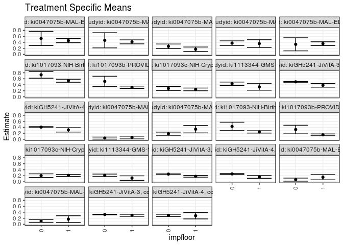

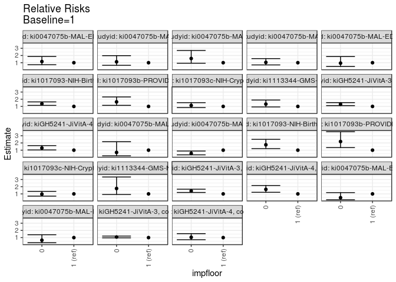

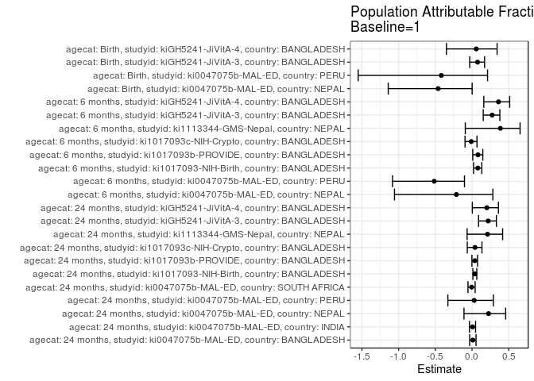

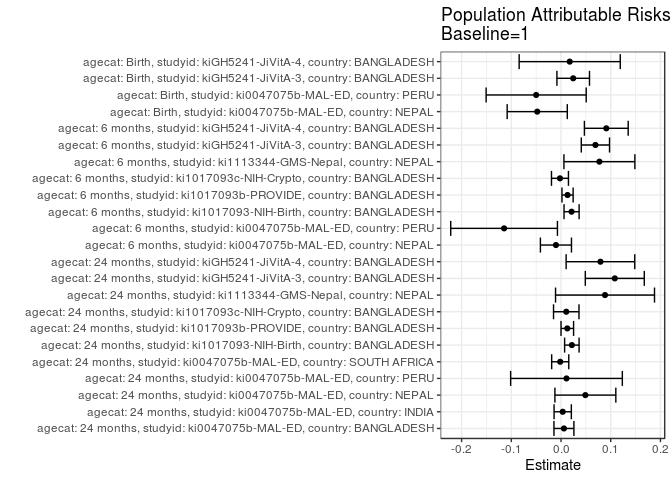

## Results Table

### Parameter: TSM

| agecat | studyid | country | intervention_level | baseline_level | estimate | ci_lower | ci_upper |
| --- | --- | --- | --- | --- | --- | --- | --- |
| Birth | ki0047075b-MAL-ED | NEPAL | 1 | NA | 0.1515152 | 0.0647482 | 0.2382821 |
| Birth | ki0047075b-MAL-ED | NEPAL | 0 | NA | 0.0714286 | 0.0202831 | 0.1225740 |
| Birth | ki0047075b-MAL-ED | PERU | 1 | NA | 0.1696917 | 0.0564674 | 0.2829159 |
| Birth | ki0047075b-MAL-ED | PERU | 0 | NA | 0.1083646 | 0.0643030 | 0.1524263 |
| Birth | kiGH5241-JiVitA-3 | BANGLADESH | 1 | NA | 0.2988537 | 0.2656466 | 0.3320608 |
| Birth | kiGH5241-JiVitA-3 | BANGLADESH | 0 | NA | 0.3242486 | 0.3163877 | 0.3321095 |
| Birth | kiGH5241-JiVitA-4 | BANGLADESH | 1 | NA | 0.2829916 | 0.1780161 | 0.3879671 |
| Birth | kiGH5241-JiVitA-4 | BANGLADESH | 0 | NA | 0.2961584 | 0.2588170 | 0.3334999 |
| 6 months | ki0047075b-MAL-ED | NEPAL | 1 | NA | 0.0582524 | 0.0129205 | 0.1035843 |
| 6 months | ki0047075b-MAL-ED | NEPAL | 0 | NA | 0.0396825 | 0.0055223 | 0.0738427 |
| 6 months | ki0047075b-MAL-ED | PERU | 1 | NA | 0.3367668 | 0.2128478 | 0.4606859 |
| 6 months | ki0047075b-MAL-ED | PERU | 0 | NA | 0.1860442 | 0.1334116 | 0.2386768 |
| 6 months | ki1017093-NIH-Birth | BANGLADESH | 1 | NA | 0.2460634 | 0.2076251 | 0.2845016 |
| 6 months | ki1017093-NIH-Birth | BANGLADESH | 0 | NA | 0.4288813 | 0.2881528 | 0.5696098 |
| 6 months | ki1017093b-PROVIDE | BANGLADESH | 1 | NA | 0.1481003 | 0.1182221 | 0.1779784 |
| 6 months | ki1017093b-PROVIDE | BANGLADESH | 0 | NA | 0.3253138 | 0.1821994 | 0.4684283 |
| 6 months | ki1017093c-NIH-Crypto | BANGLADESH | 1 | NA | 0.2119018 | 0.1774247 | 0.2463788 |
| 6 months | ki1017093c-NIH-Crypto | BANGLADESH | 0 | NA | 0.2043946 | 0.1447174 | 0.2640717 |
| 6 months | ki1113344-GMS-Nepal | NEPAL | 1 | NA | 0.1223193 | 0.0471359 | 0.1975028 |
| 6 months | ki1113344-GMS-Nepal | NEPAL | 0 | NA | 0.2141539 | 0.1717854 | 0.2565223 |
| 6 months | kiGH5241-JiVitA-3 | BANGLADESH | 1 | NA | 0.1822131 | 0.1533373 | 0.2110889 |
| 6 months | kiGH5241-JiVitA-3 | BANGLADESH | 0 | NA | 0.2561580 | 0.2477351 | 0.2645809 |
| 6 months | kiGH5241-JiVitA-4 | BANGLADESH | 1 | NA | 0.1611785 | 0.1160431 | 0.2063140 |
| 6 months | kiGH5241-JiVitA-4 | BANGLADESH | 0 | NA | 0.2624270 | 0.2469217 | 0.2779323 |
| 24 months | ki0047075b-MAL-ED | BANGLADESH | 1 | NA | 0.4564103 | 0.3863340 | 0.5264865 |
| 24 months | ki0047075b-MAL-ED | BANGLADESH | 0 | NA | 0.5294118 | 0.2915812 | 0.7672423 |
| 24 months | ki0047075b-MAL-ED | INDIA | 1 | NA | 0.4150943 | 0.3486198 | 0.4815689 |
| 24 months | ki0047075b-MAL-ED | INDIA | 0 | NA | 0.4666667 | 0.2136414 | 0.7196920 |
| 24 months | ki0047075b-MAL-ED | NEPAL | 1 | NA | 0.1682044 | 0.0935890 | 0.2428198 |
| 24 months | ki0047075b-MAL-ED | NEPAL | 0 | NA | 0.2661903 | 0.1887739 | 0.3436067 |
| 24 months | ki0047075b-MAL-ED | PERU | 1 | NA | 0.3571453 | 0.2279499 | 0.4863408 |
| 24 months | ki0047075b-MAL-ED | PERU | 0 | NA | 0.3719222 | 0.2947006 | 0.4491438 |
| 24 months | ki0047075b-MAL-ED | SOUTH AFRICA | 1 | NA | 0.3545455 | 0.2911994 | 0.4178915 |
| 24 months | ki0047075b-MAL-ED | SOUTH AFRICA | 0 | NA | 0.3333333 | 0.1151006 | 0.5515661 |
| 24 months | ki1017093-NIH-Birth | BANGLADESH | 1 | NA | 0.5355781 | 0.4853113 | 0.5858449 |
| 24 months | ki1017093-NIH-Birth | BANGLADESH | 0 | NA | 0.7327913 | 0.6203990 | 0.8451835 |
| 24 months | ki1017093b-PROVIDE | BANGLADESH | 1 | NA | 0.3166418 | 0.2769318 | 0.3563518 |
| 24 months | ki1017093b-PROVIDE | BANGLADESH | 0 | NA | 0.5165922 | 0.3473951 | 0.6857894 |
| 24 months | ki1017093c-NIH-Crypto | BANGLADESH | 1 | NA | 0.2462524 | 0.2011493 | 0.2913555 |
| 24 months | ki1017093c-NIH-Crypto | BANGLADESH | 0 | NA | 0.2790246 | 0.2124781 | 0.3455710 |
| 24 months | ki1113344-GMS-Nepal | NEPAL | 1 | NA | 0.3296389 | 0.2203998 | 0.4388779 |
| 24 months | ki1113344-GMS-Nepal | NEPAL | 0 | NA | 0.4360787 | 0.3809838 | 0.4911737 |
| 24 months | kiGH5241-JiVitA-3 | BANGLADESH | 1 | NA | 0.3824412 | 0.3219804 | 0.4429020 |
| 24 months | kiGH5241-JiVitA-3 | BANGLADESH | 0 | NA | 0.4988653 | 0.4853427 | 0.5123880 |
| 24 months | kiGH5241-JiVitA-4 | BANGLADESH | 1 | NA | 0.3129945 | 0.2413606 | 0.3846284 |
| 24 months | kiGH5241-JiVitA-4 | BANGLADESH | 0 | NA | 0.4059447 | 0.3879358 | 0.4239536 |

### Parameter: E(Y)

| agecat | studyid | country | intervention_level | baseline_level | estimate | ci_lower | ci_upper |
| --- | --- | --- | --- | --- | --- | --- | --- |
| Birth | ki0047075b-MAL-ED | NEPAL | NA | NA | 0.1036585 | 0.0568642 | 0.1504529 |
| Birth | ki0047075b-MAL-ED | PERU | NA | NA | 0.1196911 | 0.0800828 | 0.1592995 |
| Birth | kiGH5241-JiVitA-3 | BANGLADESH | NA | NA | 0.3233655 | 0.3156750 | 0.3310561 |
| Birth | kiGH5241-JiVitA-4 | BANGLADESH | NA | NA | 0.3004866 | 0.2649179 | 0.3360553 |
| 6 months | ki0047075b-MAL-ED | NEPAL | NA | NA | 0.0480349 | 0.0202781 | 0.0757918 |
| 6 months | ki0047075b-MAL-ED | PERU | NA | NA | 0.2222222 | 0.1725409 | 0.2719036 |
| 6 months | ki1017093-NIH-Birth | BANGLADESH | NA | NA | 0.2672897 | 0.2297549 | 0.3048246 |
| 6 months | ki1017093b-PROVIDE | BANGLADESH | NA | NA | 0.1612350 | 0.1313580 | 0.1911120 |
| 6 months | ki1017093c-NIH-Crypto | BANGLADESH | NA | NA | 0.2097902 | 0.1799252 | 0.2396552 |
| 6 months | ki1113344-GMS-Nepal | NEPAL | NA | NA | 0.1995465 | 0.1622033 | 0.2368897 |
| 6 months | kiGH5241-JiVitA-3 | BANGLADESH | NA | NA | 0.2514160 | 0.2432636 | 0.2595684 |
| 6 months | kiGH5241-JiVitA-4 | BANGLADESH | NA | NA | 0.2522803 | 0.2382170 | 0.2663435 |
| 24 months | ki0047075b-MAL-ED | BANGLADESH | NA | NA | 0.4622642 | 0.3949918 | 0.5295365 |
| 24 months | ki0047075b-MAL-ED | INDIA | NA | NA | 0.4185022 | 0.3541865 | 0.4828179 |
| 24 months | ki0047075b-MAL-ED | NEPAL | NA | NA | 0.2171946 | 0.1627082 | 0.2716810 |
| 24 months | ki0047075b-MAL-ED | PERU | NA | NA | 0.3681592 | 0.3013164 | 0.4350020 |
| 24 months | ki0047075b-MAL-ED | SOUTH AFRICA | NA | NA | 0.3529412 | 0.2921001 | 0.4137823 |
| 24 months | ki1017093-NIH-Birth | BANGLADESH | NA | NA | 0.5573770 | 0.5102104 | 0.6045437 |
| 24 months | ki1017093b-PROVIDE | BANGLADESH | NA | NA | 0.3292894 | 0.2909105 | 0.3676684 |
| 24 months | ki1017093c-NIH-Crypto | BANGLADESH | NA | NA | 0.2568093 | 0.2190047 | 0.2946140 |
| 24 months | ki1113344-GMS-Nepal | NEPAL | NA | NA | 0.4181818 | 0.3688464 | 0.4675172 |
| 24 months | kiGH5241-JiVitA-3 | BANGLADESH | NA | NA | 0.4906493 | 0.4775353 | 0.5037634 |
| 24 months | kiGH5241-JiVitA-4 | BANGLADESH | NA | NA | 0.3923304 | 0.3753233 | 0.4093375 |

### Parameter: RR

| agecat | studyid | country | intervention_level | baseline_level | estimate | ci_lower | ci_upper |
| --- | --- | --- | --- | --- | --- | --- | --- |
| Birth | ki0047075b-MAL-ED | NEPAL | 1 | 1 | 1.0000000 | 1.0000000 | 1.0000000 |
| Birth | ki0047075b-MAL-ED | NEPAL | 0 | 1 | 0.4714286 | 0.1884624 | 1.1792534 |
| Birth | ki0047075b-MAL-ED | PERU | 1 | 1 | 1.0000000 | 1.0000000 | 1.0000000 |
| Birth | ki0047075b-MAL-ED | PERU | 0 | 1 | 0.6385973 | 0.2918786 | 1.3971783 |
| Birth | kiGH5241-JiVitA-3 | BANGLADESH | 1 | 1 | 1.0000000 | 1.0000000 | 1.0000000 |
| Birth | kiGH5241-JiVitA-3 | BANGLADESH | 0 | 1 | 1.0849744 | 0.9687510 | 1.2151413 |
| Birth | kiGH5241-JiVitA-4 | BANGLADESH | 1 | 1 | 1.0000000 | 1.0000000 | 1.0000000 |
| Birth | kiGH5241-JiVitA-4 | BANGLADESH | 0 | 1 | 1.0465272 | 0.7078250 | 1.5473022 |
| 6 months | ki0047075b-MAL-ED | NEPAL | 1 | 1 | 1.0000000 | 1.0000000 | 1.0000000 |
| 6 months | ki0047075b-MAL-ED | NEPAL | 0 | 1 | 0.6812169 | 0.2134571 | 2.1740031 |
| 6 months | ki0047075b-MAL-ED | PERU | 1 | 1 | 1.0000000 | 1.0000000 | 1.0000000 |
| 6 months | ki0047075b-MAL-ED | PERU | 0 | 1 | 0.5524421 | 0.3477743 | 0.8775584 |
| 6 months | ki1017093-NIH-Birth | BANGLADESH | 1 | 1 | 1.0000000 | 1.0000000 | 1.0000000 |
| 6 months | ki1017093-NIH-Birth | BANGLADESH | 0 | 1 | 1.7429709 | 1.2146033 | 2.5011851 |
| 6 months | ki1017093b-PROVIDE | BANGLADESH | 1 | 1 | 1.0000000 | 1.0000000 | 1.0000000 |
| 6 months | ki1017093b-PROVIDE | BANGLADESH | 0 | 1 | 2.1965785 | 1.3563383 | 3.5573403 |
| 6 months | ki1017093c-NIH-Crypto | BANGLADESH | 1 | 1 | 1.0000000 | 1.0000000 | 1.0000000 |
| 6 months | ki1017093c-NIH-Crypto | BANGLADESH | 0 | 1 | 0.9645723 | 0.6908789 | 1.3466900 |
| 6 months | ki1113344-GMS-Nepal | NEPAL | 1 | 1 | 1.0000000 | 1.0000000 | 1.0000000 |
| 6 months | ki1113344-GMS-Nepal | NEPAL | 0 | 1 | 1.7507773 | 0.9173191 | 3.3414991 |
| 6 months | kiGH5241-JiVitA-3 | BANGLADESH | 1 | 1 | 1.0000000 | 1.0000000 | 1.0000000 |
| 6 months | kiGH5241-JiVitA-3 | BANGLADESH | 0 | 1 | 1.4058157 | 1.1980622 | 1.6495954 |
| 6 months | kiGH5241-JiVitA-4 | BANGLADESH | 1 | 1 | 1.0000000 | 1.0000000 | 1.0000000 |
| 6 months | kiGH5241-JiVitA-4 | BANGLADESH | 0 | 1 | 1.6281760 | 1.2224069 | 2.1686373 |
| 24 months | ki0047075b-MAL-ED | BANGLADESH | 1 | 1 | 1.0000000 | 1.0000000 | 1.0000000 |
| 24 months | ki0047075b-MAL-ED | BANGLADESH | 0 | 1 | 1.1599471 | 0.7215350 | 1.8647429 |
| 24 months | ki0047075b-MAL-ED | INDIA | 1 | 1 | 1.0000000 | 1.0000000 | 1.0000000 |
| 24 months | ki0047075b-MAL-ED | INDIA | 0 | 1 | 1.1242424 | 0.6387494 | 1.9787432 |
| 24 months | ki0047075b-MAL-ED | NEPAL | 1 | 1 | 1.0000000 | 1.0000000 | 1.0000000 |
| 24 months | ki0047075b-MAL-ED | NEPAL | 0 | 1 | 1.5825407 | 0.9280030 | 2.6987360 |
| 24 months | ki0047075b-MAL-ED | PERU | 1 | 1 | 1.0000000 | 1.0000000 | 1.0000000 |
| 24 months | ki0047075b-MAL-ED | PERU | 0 | 1 | 1.0413748 | 0.6911610 | 1.5690433 |
| 24 months | ki0047075b-MAL-ED | SOUTH AFRICA | 1 | 1 | 1.0000000 | 1.0000000 | 1.0000000 |
| 24 months | ki0047075b-MAL-ED | SOUTH AFRICA | 0 | 1 | 0.9401709 | 0.4769548 | 1.8532602 |
| 24 months | ki1017093-NIH-Birth | BANGLADESH | 1 | 1 | 1.0000000 | 1.0000000 | 1.0000000 |
| 24 months | ki1017093-NIH-Birth | BANGLADESH | 0 | 1 | 1.3682249 | 1.1475740 | 1.6313018 |
| 24 months | ki1017093b-PROVIDE | BANGLADESH | 1 | 1 | 1.0000000 | 1.0000000 | 1.0000000 |
| 24 months | ki1017093b-PROVIDE | BANGLADESH | 0 | 1 | 1.6314719 | 1.1485772 | 2.3173894 |
| 24 months | ki1017093c-NIH-Crypto | BANGLADESH | 1 | 1 | 1.0000000 | 1.0000000 | 1.0000000 |
| 24 months | ki1017093c-NIH-Crypto | BANGLADESH | 0 | 1 | 1.1330837 | 0.8435935 | 1.5219163 |
| 24 months | ki1113344-GMS-Nepal | NEPAL | 1 | 1 | 1.0000000 | 1.0000000 | 1.0000000 |
| 24 months | ki1113344-GMS-Nepal | NEPAL | 0 | 1 | 1.3228984 | 0.9286206 | 1.8845804 |
| 24 months | kiGH5241-JiVitA-3 | BANGLADESH | 1 | 1 | 1.0000000 | 1.0000000 | 1.0000000 |
| 24 months | kiGH5241-JiVitA-3 | BANGLADESH | 0 | 1 | 1.3044236 | 1.1118683 | 1.5303261 |
| 24 months | kiGH5241-JiVitA-4 | BANGLADESH | 1 | 1 | 1.0000000 | 1.0000000 | 1.0000000 |
| 24 months | kiGH5241-JiVitA-4 | BANGLADESH | 0 | 1 | 1.2969710 | 1.0292509 | 1.6343281 |

### Parameter: PAR

| agecat | studyid | country | intervention_level | baseline_level | estimate | ci_lower | ci_upper |
| --- | --- | --- | --- | --- | --- | --- | --- |
| Birth | ki0047075b-MAL-ED | NEPAL | 1 | NA | -0.0478566 | -0.1083437 | 0.0126305 |
| Birth | ki0047075b-MAL-ED | PERU | 1 | NA | -0.0500005 | -0.1506693 | 0.0506682 |
| Birth | kiGH5241-JiVitA-3 | BANGLADESH | 1 | NA | 0.0245118 | -0.0082534 | 0.0572771 |
| Birth | kiGH5241-JiVitA-4 | BANGLADESH | 1 | NA | 0.0174950 | -0.0842004 | 0.1191905 |
| 6 months | ki0047075b-MAL-ED | NEPAL | 1 | NA | -0.0102175 | -0.0414719 | 0.0210369 |
| 6 months | ki0047075b-MAL-ED | PERU | 1 | NA | -0.1145446 | -0.2218996 | -0.0071896 |
| 6 months | ki1017093-NIH-Birth | BANGLADESH | 1 | NA | 0.0212263 | 0.0060579 | 0.0363947 |
| 6 months | ki1017093b-PROVIDE | BANGLADESH | 1 | NA | 0.0131347 | 0.0018923 | 0.0243772 |
| 6 months | ki1017093c-NIH-Crypto | BANGLADESH | 1 | NA | -0.0021116 | -0.0191888 | 0.0149657 |
| 6 months | ki1113344-GMS-Nepal | NEPAL | 1 | NA | 0.0772272 | 0.0058585 | 0.1485958 |
| 6 months | kiGH5241-JiVitA-3 | BANGLADESH | 1 | NA | 0.0692029 | 0.0407945 | 0.0976113 |
| 6 months | kiGH5241-JiVitA-4 | BANGLADESH | 1 | NA | 0.0911017 | 0.0470521 | 0.1351514 |
| 24 months | ki0047075b-MAL-ED | BANGLADESH | 1 | NA | 0.0058539 | -0.0142072 | 0.0259150 |
| 24 months | ki0047075b-MAL-ED | INDIA | 1 | NA | 0.0034079 | -0.0139598 | 0.0207755 |
| 24 months | ki0047075b-MAL-ED | NEPAL | 1 | NA | 0.0489902 | -0.0122973 | 0.1102776 |
| 24 months | ki0047075b-MAL-ED | PERU | 1 | NA | 0.0110139 | -0.1013493 | 0.1233770 |
| 24 months | ki0047075b-MAL-ED | SOUTH AFRICA | 1 | NA | -0.0016043 | -0.0188054 | 0.0155968 |
| 24 months | ki1017093-NIH-Birth | BANGLADESH | 1 | NA | 0.0217990 | 0.0072365 | 0.0363614 |
| 24 months | ki1017093b-PROVIDE | BANGLADESH | 1 | NA | 0.0126476 | 0.0000124 | 0.0252828 |
| 24 months | ki1017093c-NIH-Crypto | BANGLADESH | 1 | NA | 0.0105569 | -0.0150567 | 0.0361706 |
| 24 months | ki1113344-GMS-Nepal | NEPAL | 1 | NA | 0.0885429 | -0.0110110 | 0.1880968 |
| 24 months | kiGH5241-JiVitA-3 | BANGLADESH | 1 | NA | 0.1082081 | 0.0488691 | 0.1675472 |
| 24 months | kiGH5241-JiVitA-4 | BANGLADESH | 1 | NA | 0.0793359 | 0.0103014 | 0.1483704 |

### Parameter: PAF

| agecat | studyid | country | intervention_level | baseline_level | estimate | ci_lower | ci_upper |
| --- | --- | --- | --- | --- | --- | --- | --- |
| Birth | ki0047075b-MAL-ED | NEPAL | 1 | NA | -0.4616756 | -1.1416400 | 0.0024021 |
| Birth | ki0047075b-MAL-ED | PERU | 1 | NA | -0.4177464 | -1.5514096 | 0.2121983 |
| Birth | kiGH5241-JiVitA-3 | BANGLADESH | 1 | NA | 0.0758023 | -0.0311848 | 0.1716892 |
| Birth | kiGH5241-JiVitA-4 | BANGLADESH | 1 | NA | 0.0582223 | -0.3483110 | 0.3421804 |
| 6 months | ki0047075b-MAL-ED | NEPAL | 1 | NA | -0.2127096 | -1.0563292 | 0.2848107 |
| 6 months | ki0047075b-MAL-ED | PERU | 1 | NA | -0.5154507 | -1.0830843 | -0.1024954 |
| 6 months | ki1017093-NIH-Birth | BANGLADESH | 1 | NA | 0.0794132 | 0.0213971 | 0.1339898 |
| 6 months | ki1017093b-PROVIDE | BANGLADESH | 1 | NA | 0.0814633 | 0.0103314 | 0.1474826 |
| 6 months | ki1017093c-NIH-Crypto | BANGLADESH | 1 | NA | -0.0100651 | -0.0948425 | 0.0681476 |
| 6 months | ki1113344-GMS-Nepal | NEPAL | 1 | NA | 0.3870134 | -0.0913948 | 0.6557134 |
| 6 months | kiGH5241-JiVitA-3 | BANGLADESH | 1 | NA | 0.2752525 | 0.1534570 | 0.3795248 |
| 6 months | kiGH5241-JiVitA-4 | BANGLADESH | 1 | NA | 0.3611132 | 0.1609479 | 0.5135269 |
| 24 months | ki0047075b-MAL-ED | BANGLADESH | 1 | NA | 0.0126635 | -0.0317304 | 0.0551472 |
| 24 months | ki0047075b-MAL-ED | INDIA | 1 | NA | 0.0081430 | -0.0342453 | 0.0487940 |
| 24 months | ki0047075b-MAL-ED | NEPAL | 1 | NA | 0.2255589 | -0.1089046 | 0.4591428 |
| 24 months | ki0047075b-MAL-ED | PERU | 1 | NA | 0.0299160 | -0.3286216 | 0.2916998 |
| 24 months | ki0047075b-MAL-ED | SOUTH AFRICA | 1 | NA | -0.0045455 | -0.0544841 | 0.0430282 |
| 24 months | ki1017093-NIH-Birth | BANGLADESH | 1 | NA | 0.0391099 | 0.0121899 | 0.0652963 |
| 24 months | ki1017093b-PROVIDE | BANGLADESH | 1 | NA | 0.0384088 | -0.0007422 | 0.0760282 |
| 24 months | ki1017093c-NIH-Crypto | BANGLADESH | 1 | NA | 0.0411081 | -0.0640285 | 0.1358562 |
| 24 months | ki1113344-GMS-Nepal | NEPAL | 1 | NA | 0.2117331 | -0.0665448 | 0.4174041 |
| 24 months | kiGH5241-JiVitA-3 | BANGLADESH | 1 | NA | 0.2205407 | 0.0897122 | 0.3325662 |
| 24 months | kiGH5241-JiVitA-4 | BANGLADESH | 1 | NA | 0.2022171 | 0.0047158 | 0.3605268 |